# Econometria III Aula 1

Mestrado Profissional em Administração

Prof. Dr. Washington Santos da Silva

05/10/2026

## Programação da aula

- Estruturas de dados
- Efeitos Fixos: Visão Intuitiva
- Modelo de efeitos fixos: formulação e estimação
- Atividade 1

Estruturas de dados em Econometria

## Estruturas de dados em Econometria

- **Dados de corte transversal** (*cross-section data*)
- **Dados de séries temporais** (*time series data*)
- **Cortes transversais repetidos** (*repeated cross-sections*)
- **Dados em painel** (*panel data*)

## Dados de corte transversal (*cross-section*)

Em dados de **corte transversal**, observamos diferentes unidades em um determinado período.

Considere os trabalhadores observados em 2020:

| ID | Ano | Salário/hora | Educação (anos) |
| --- | --- | --- | --- |
| A | 2020 | 24,00 | 12 |
| B | 2020 | 31,00 | 16 |
| C | 2020 | 20,00 | 11 |

Cada trabalhador aparece **uma única vez**. O ano identifica o período do corte, mas não acompanhamos A, B ou C em outros momentos.

Nesse exemplo, a ordem A, B e C na base não representa uma sequência temporal: o que importa é que observamos **unidades diferentes no mesmo corte**.

## Análises com dados de corte transversal

Em um corte transversal, a variação disponível para análise ocorre **entre unidades observadas no mesmo período**.

Por exemplo, podemos estudar a associação entre educação e salário em 2020:

$$salario_i = \beta_0 + \beta_1 educacao_i + \varepsilon_i$$

Nesse modelo, $\beta_1$ representa a diferença esperada no salário associada a **um ano adicional de educação**.

Também podemos comparar grupos usando uma variável indicadora:

$$salario_i = \beta_0 + \beta_1 grupo_i + \varepsilon_i$$

Nesse caso, $\beta_1$ representa a diferença entre o **salário médio do grupo indicado por 1** e o **salário médio do grupo de referência**.

Como cada trabalhador aparece apenas uma vez, essa estrutura **não permite observar como o salário da mesma pessoa muda ao longo do tempo**.

## Dados de séries temporais (*time series*)

Em uma **série temporal**, uma ou mais variáveis referentes à mesma unidade ou agregado são observadas em diferentes períodos.

Considere, por exemplo, um mesmo mercado de trabalho regional observado anualmente:

| Ano | Salário médio/hora | Taxa de desemprego (%) |
| --- | --- | --- |
| 2020 | 27,00 | 8,0 |
| 2021 | 28,00 | 7,4 |
| 2022 | 29,50 | 6,8 |
| 2023 | 31,00 | 6,2 |
| 2024 | 32,50 | 5,9 |

*Valores apenas ilustrativos.*

Agora, a **ordem cronológica faz parte da informação**: valores observados em um período podem estar relacionados aos valores observados em períodos anteriores.

## Análises com séries temporais

A dimensão temporal permite estudar como uma ou mais variáveis **evoluem ao longo do tempo**.

- identificar tendências e outras mudanças ao longo do período observado;
- estudar **dinâmica temporal**, incluindo relações entre valores presentes e passados;
- analisar padrões associados à frequência dos dados, como sazonalidade, quando pertinente;
- utilizar a informação temporal para realizar previsões.

Mas uma série do salário médio de uma região, por exemplo, **não mostra como diferentes trabalhadores se distinguem entre si em determinado ano**.

Nesse caso, observamos a variação do **agregado ao longo do tempo**, e não a variação entre várias unidades individuais em um mesmo período.

## Dados de cortes transversais repetidos (*repeated cross-sections*)

- **Cortes transversais repetidos**: novas amostras de corte transversal obtidas em diferentes períodos.
- Não há um desenho de acompanhamento das mesmas unidades ao longo do tempo.

## Exemplo: cortes transversais repetidos

Considere que, em 2020 e 2024, são selecionadas novas amostras da população de trabalhadores; em cada ano, registram-se o salário por hora e os anos de educação de cada pessoa observada.

| ID | Ano | Salário/hora | Educação (anos) |
| --- | --- | --- | --- |
| A | 2020 | 24,00 | 12 |
| B | 2020 | 31,00 | 16 |
| C | 2020 | 20,00 | 11 |
| D | 2024 | 28,00 | 13 |
| E | 2024 | 36,00 | 16 |
| F | 2024 | 23,00 | 12 |

*Os IDs apenas ilustram novas amostras; uma mesma pessoa poderia aparecer novamente por acaso.*

## Amostragem e independência

- No caso considerado por Wooldridge, em cada período obtém-se uma **amostra aleatória** da população; ao combinar esses cortes, as observações são **amostradas independentemente**.
- Essa independência é estatisticamente importante: entre outras coisas, exclui correlação entre os termos de erro de observações distintas.
- **Independência não implica distribuição idêntica ao longo do tempo**: como a população pode mudar, distribuições de variáveis como salários e educação também podem mudar entre períodos.

## Análises com cortes transversais repetidos

Com amostras de 2020 e 2024, podemos estudar se **resultados ou relações diferem entre os períodos**.

Para comparar o salário médio:

$$salario_i = \beta_0 + \beta_1 ano2024_i + \varepsilon_i,$$

em que `ano2024 = 1` para 2024 e `ano2024 = 0` para 2020.

Nesse modelo, $\beta_0$ é o salário médio em 2020 e $\beta_1$ é a **diferença entre o salário médio de 2024 e o de 2020**. Como temos novas amostras, essa diferença não representa a mudança do salário dos mesmos trabalhadores.

Também podemos estudar se uma **relação mudou entre os períodos**:

$$salario_i = \beta_0 + \beta_1 educacao_i + \beta_2 ano2024_i +
\beta_3(educacao_i \times ano2024_i) + \varepsilon_i.$$

Aqui, $\beta_1$ representa a associação entre educação e salário em 2020, enquanto $\beta_3$ indica quanto essa associação difere em 2024.

Cortes transversais repetidos também podem ser utilizados em aplicações de **Diferenças em Diferenças (DiD)**, que serão estudadas posteriormente.

## Dados em painel (*panel data*)

- **Dados em painel** também possuem dimensões de corte transversal e temporal.
- As mesmas unidades são identificadas e observadas ao longo do tempo, ainda que nem todas precisem ser observadas em todos os períodos.
- Essas unidades podem ser indivíduos, famílias, firmas, cidades ou estados.

## Exemplo: dados em painel

Considere que os mesmos trabalhadores selecionados em 2020 são acompanhados novamente em 2024; em ambos os anos, registram-se o salário por hora e os anos de educação de cada pessoa.

| ID | Ano | Salário/hora | Educação (anos) |
| --- | --- | --- | --- |
| A | 2020 | 24,00 | 12 |
| A | 2024 | 29,00 | 12 |
| B | 2020 | 31,00 | 16 |
| B | 2024 | 38,00 | 16 |
| C | 2020 | 20,00 | 11 |
| C | 2024 | 25,00 | 12 |

*Os mesmos IDs reaparecem nos diferentes períodos: as mesmas pessoas são acompanhadas ao longo do tempo.*

*Este exemplo é um painel **balanceado**, com $N=3$ unidades e $T=2$ períodos: todas as unidades são observadas nos dois períodos.*

Em um painel **desbalanceado**, algumas unidades não são observadas em todos os períodos.

## Amostragem e independência

- Um painel pode começar com uma **amostra aleatória** de unidades; depois, essas mesmas unidades são acompanhadas em períodos posteriores.
- Portanto, **seleção aleatória das unidades não implica independência entre as observações da mesma unidade ao longo do tempo**.
- As observações de uma mesma unidade **podem ser estatisticamente dependentes** ao longo do tempo.
- Uma fonte dessa dependência é a **heterogeneidade específica da unidade invariável no tempo**: por exemplo, a habilidade que afeta o salário de uma pessoa em um ano também pode afetá-lo no ano seguinte.

## Análises com dados em painel

Em dados em painel, observamos simultaneamente duas fontes de variação:

| Fonte de variação | No exemplo dos trabalhadores |
| --- | --- |
| **Entre unidades** | em 2020, podemos comparar A, B e C |
| **Dentro da mesma unidade** | podemos acompanhar A de 2020 a 2024, e fazer o mesmo com B e C |

Isso permite observar não apenas **como trabalhadores diferem entre si**, mas também **como uma mesma pessoa muda ao longo do tempo**.

Por exemplo, podemos investigar se trabalhadores que apresentam mudanças em uma característica observada ao longo do tempo também apresentam mudanças em seu salário.

O painel fornece, portanto, informação tanto sobre **diferenças entre unidades** quanto sobre **mudanças dentro da mesma unidade ao longo do tempo**.

Como explorar econometricamente essas duas fontes de variação será desenvolvido posteriormente.

Efeitos fixos: visão intuitiva

## Os dados

Um treinador acompanha as **horas de treinamento** e o **desempenho** de seus atletas.

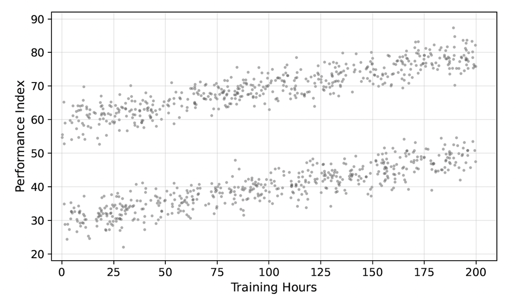

Figura 1: Gráfico de dispersão de Training Hours no eixo horizontal e Performance Index no eixo vertical. Os pontos formam duas faixas aproximadamente paralelas, uma com desempenho mais baixo e outra com desempenho mais alto.

**Como esses dados poderiam ter sido gerados?**

## A estrutura do problema

Na verdade, existem duas equipes: **Varsity** e **Junior Varsity (JV)**. Mesmo programa de treinamento, mas diferentes **níveis de habilidade não observada**.

Vamos supor que:

- essa diferença de habilidade gere um intercepto de 30 para a JV e de 60 para a Varsity no desempenho esperado;
- cada 10 horas adicionais de treinamento $\rightarrow$ +1 ponto de desempenho (inclinação = 0,1).

Como este é um exemplo simulado, conhecemos a inclinação verdadeira por construção: $\beta_1=0{,}10$.

Se ignorarmos a equipe e estimarmos uma única regressão:

$$\text{Desempenho}_i
=
\underbrace{\beta_0}_{\substack{\text{mesmo intercepto}\\\text{para as duas equipes}}}
+
\underbrace{\beta_1}_{\substack{\text{mesma inclinação}\\\text{para ambas — OK}}}
\text{Horas}_i
+
\varepsilon_i.$$

## A estrutura do problema

Mas a diferença de habilidade não observada gera **interceptos distintos**: 30 para a JV e 60 para a Varsity.

Um único $\beta_0$ não pode representar corretamente os dois grupos.

Questão: o que acontece quando impomos um único intercepto a dados com dois?

## O que acontece com um MQO agrupado ingênuo?

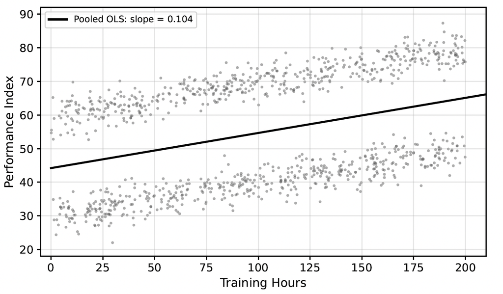

Figura 2: Mesmo gráfico de dispersão do slide 2, agora com uma única reta de MQO agrupada atravessando os dois grupos. MQO agrupado (*pooled OLS*): inclinação $\approx 0{,}10$ — parece correta!

Neste cenário, as **horas médias de treinamento são aproximadamente iguais** nos dois grupos: equipe e horas de treinamento não apresentam associação linear relevante.

**E se isso mudar?**

## Primeira verificação: as horas de treinamento diferem entre os grupos?

Na prática, a distribuição de $x$ pode diferir entre grupos.

- Atletas da Varsity podem treinar mais.
- Ou atletas da JV podem treinar mais.

**Questão-chave:** Equipe e horas de treinamento **estão associadas?**

Se sim, como as equipes possuem **diferentes níveis de habilidade não observada**, que geram diferenças no desempenho esperado, o MQO agrupado pode atribuir às horas de treinamento parte da diferença entre os grupos.

Isso gera **viés por variável omitida**.

## Cenário: Varsity treina mais

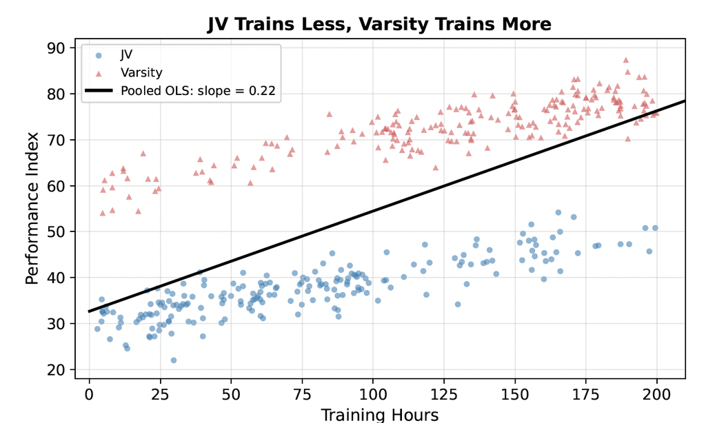

Figura 3: Gráfico de dispersão com JV e Varsity identificadas separadamente. A JV concentra-se em menos horas de treinamento e menor desempenho; Varsity, em mais horas e maior desempenho. Inclinação de MQO = **0,22** (verdadeira = 0,10).

O viés é **positivo**: o MQO agrupado atribui às maiores horas de treinamento parte do maior desempenho da Varsity decorrente de sua maior **habilidade não observada**.

## Cenário: JV treina mais

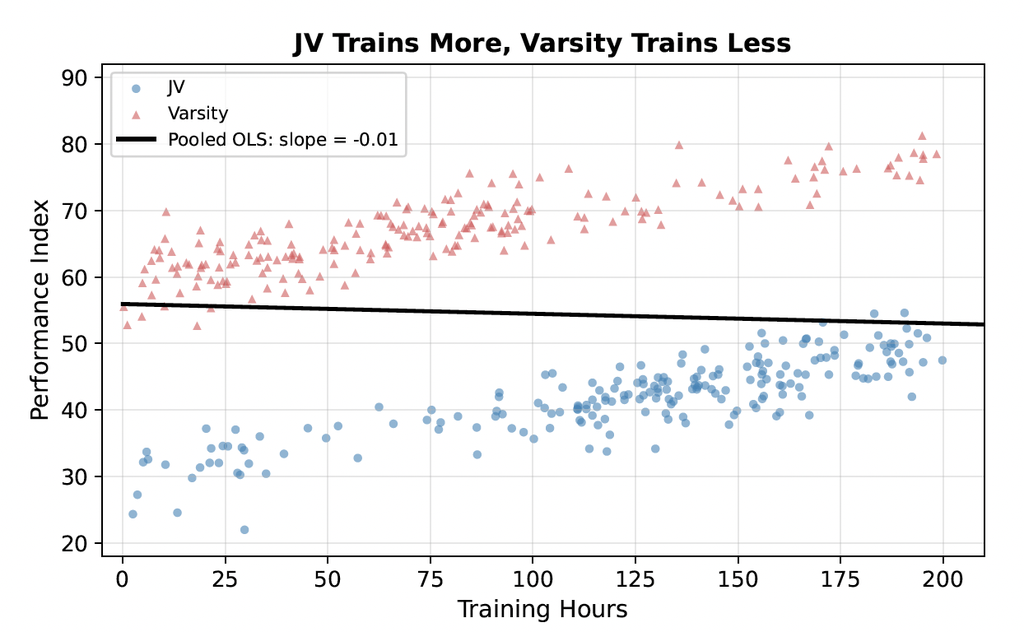

Figura 4: Gráfico de dispersão com JV e Varsity identificadas separadamente. A JV concentra-se em mais horas de treinamento e menor desempenho; Varsity, em menos horas e maior desempenho. A reta de MQO agrupado aparece praticamente horizontal. Inclinação de MQO = **ligeiramente negativa e próxima de zero** (verdadeira = 0,10).

O viés é **negativo**: a relação agrupada se torna ligeiramente negativa e próxima de zero porque a JV treina mais, mas possui menor **habilidade não observada**.

## Paradoxo de Simpson:

### A agregação pode inverter a associação

No cenário **“JV treina mais”**, aparecem duas relações diferentes:

- **dentro de cada equipe**, mais horas de treinamento estão associadas a maior desempenho: a inclinação é positiva ($\beta_1=0{,}10$);
- **nos dados agrupados**, a inclinação de MQO é ligeiramente negativa.

Essa **reversão de sinal** é um exemplo do **paradoxo de Simpson**:

> uma associação observada nos dados agregados pode ter direção oposta à associação observada dentro dos grupos.

## Paradoxo de Simpson:

### A agregação pode inverter a associação

Nesse caso, a reversão ocorre porque:

- JV e Varsity possuem **diferentes níveis não observados de habilidade**, que geram diferenças no nível esperado de desempenho;
- a equipe está **associada às horas de treinamento**.

Ao agrupar os dados, misturamos a **variação dentro das equipes** com as **diferenças entre as equipes**.

O paradoxo não é uma contradição: ele mostra que a relação agregada pode mudar quando condicionamos a análise a um grupo relevante.

No cenário **“Varsity treina mais”**, há viés na inclinação, mas não há paradoxo de Simpson, pois o sinal não se inverte.

## Quando uma variável omitida gera viés?

Omitir uma variável **não gera necessariamente viés** no coeficiente de outra regressora.

Para que a omissão de $X_2$ altere a estimativa do coeficiente de $X_1$, duas condições precisam ocorrer conjuntamente:

1. $X_2$ contribui para explicar $Y$, mesmo controlando por $X_1$ ($\beta_2\neq0$);
2. $X_2$ está associada à regressora incluída $X_1$ ($\delta_1\neq0$).

No nosso exemplo:

- **equipe e desempenho:** a equipe captura diferenças de habilidade não observada que geram diferentes níveis esperados de desempenho;
- **equipe e horas:** nos cenários anteriores, as equipes treinam, em média, quantidades diferentes de horas.

Assim, ao omitir `equipe`, o MQO agrupado pode atribuir às **horas de treino** parte da diferença de desempenho associada à equipe.

Se **uma dessas duas condições não estiver presente**, a omissão de $X_2$ não gera viés na estimativa de $\beta_1$.

**Como podemos representar esse mecanismo formalmente?**

## O viés por variável omitida

Vamos agora formalizar esse mecanismo. No nosso exemplo,

$$Y_i=\text{desempenho},
\qquad
X_{1i}=\text{horas},
\qquad
X_{2i}=
\begin{cases}
1, & \text{Varsity},\\
0, & \text{JV}.
\end{cases}$$

**Regressão curta** — omite $X_2$:

$$Y_i=\beta_0+\beta_1X_{1i}+\eta_i.$$

**Regressão longa** — inclui $X_2$:

$$Y_i=\beta_0+\beta_1X_{1i}+\beta_2X_{2i}+\varepsilon_i.$$

**Regressão auxiliar** — relação entre a variável incluída e a omitida:

$$X_{2i}=\delta_0+\delta_1X_{1i}+\xi_i.$$

**Fórmula do viés por variável omitida:**

$$\hat{\beta}_1^{\text{curta}}
=
\hat{\beta}_1^{\text{longa}}
+
\underbrace{\hat{\beta}_2}_{\substack{\text{coeficiente}\\\text{de }X_2}}
\times
\underbrace{\hat{\delta}_1}_{\substack{\text{relação de }X_2\\\text{com }X_1}}.$$

## Aplicando o viés por variável omitida ao exemplo

$$\hat{\beta}_1^{\text{curta}}
=
\underbrace{\hat{\beta}_1^{\text{longa}}}_{\approx\,0{,}10}
+
\underbrace{\hat{\beta}_2}_{\substack{\text{diferença de desempenho}\\
\text{associada à equipe, dadas as horas}}}
\times
\underbrace{\hat{\delta}_1}_{\substack{\text{relação da equipe}\\
\text{com as horas}}}.$$

Como $X_2=1$ para Varsity e $X_2=0$ para JV, e a maior **habilidade não observada** da Varsity desloca seu desempenho esperado para cima, temos $\hat{\beta}_2>0$.

| Cenário | $\hat{\delta}_1$ | Viés $(\hat{\beta}_2\times\hat{\delta}_1)$ | Inclinação MQO |
| --- | --- | --- | --- |
| Varsity treina mais | $>0$ | $+$ | 0,22 |
| JV treina mais | $<0$ | $-$ | $<0$, próxima de 0 |
| Horas médias semelhantes | $\approx0$ | $\approx0$ | 0,10 |

**Mesma inclinação verdadeira por construção, diferentes padrões de associação entre equipe e horas.** A estimativa de MQO varia de uma inclinação ligeiramente negativa, próxima de zero, a 0,22, embora a inclinação verdadeira permaneça $\beta_1=0{,}10$.

## E se a composição dos grupos for desigual?

Suponha que as **horas médias de treinamento sejam aproximadamente iguais** nos dois grupos $(\hat{\delta}_1\approx0)$, mas que suas participações na amostra sejam diferentes.

- A inclinação muda?
- E o intercepto?

A **composição desigual dos grupos, por si só, não gera viés na inclinação**.

Como equipe e horas de treinamento continuam sem associação linear relevante, a inclinação do MQO agrupado pode permanecer aproximadamente correta.

O intercepto, porém, **é sensível à composição da amostra**: quanto maior a participação de um grupo, mais o intercepto agrupado tende a se deslocar em direção ao **intercepto verdadeiro desse grupo**.

$\Longrightarrow$ Um único intercepto continua inadequado para representar corretamente os dois grupos.

## 80% JV, 20% Varsity

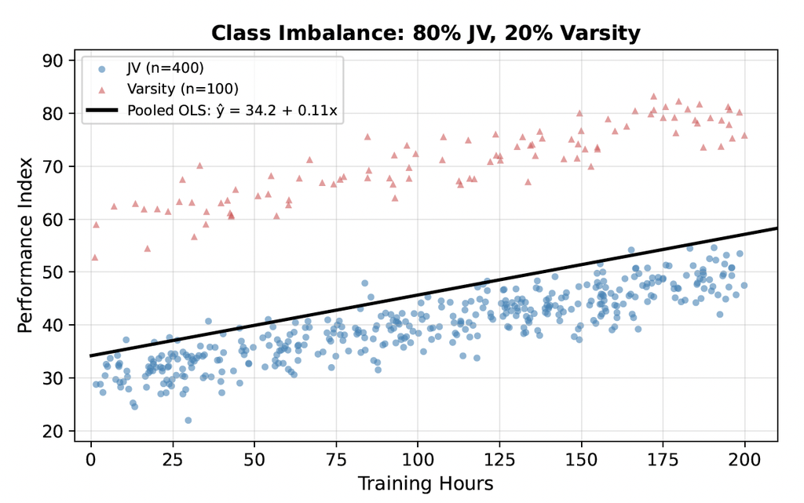

Figura 5: Composição da amostra com JV n=400 e Varsity n=100. Inclinação $\approx$ correta. Intercepto = **34** — deslocado em direção ao verdadeiro intercepto da JV (30).

As previsões do modelo ficam **sistematicamente deslocadas** para os atletas da Varsity.

## 20% JV, 80% Varsity

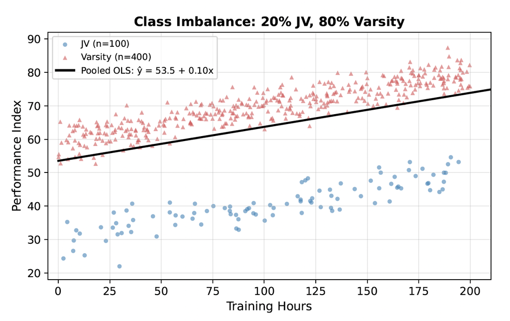

Figura 6: Composição da amostra com JV n=100 e Varsity n=400. Inclinação $\approx$ correta. Intercepto = **54** — deslocado em direção ao verdadeiro intercepto da Varsity (60).

Agora as previsões do modelo ficam **sistematicamente deslocadas** para os atletas da JV.

## Composição dos grupos: o intercepto agrupado se desloca

| Amostra | Intercepto MQO | JV verdadeira $(\alpha=30)$ | Varsity verdadeira $(\alpha=60)$ |
| --- | --- | --- | --- |
| 80% JV | 34 | próximo | erro de 26 |
| 50/50 | 44 | erro de 14 | erro de 16 |
| 80% Varsity | 54 | erro de 24 | próximo |

$\Longrightarrow$ Mesmo quando a inclinação está aproximadamente correta, o MQO agrupado utiliza **um único intercepto que está errado para cada subgrupo**.

O erro depende da composição da amostra, que o analista/pesquisador pode não controlar.

## Um intercepto separado para cada grupo

Todos os exemplos “ingênuos” anteriores utilizaram o mesmo modelo:

$$y_i=\beta_0+\beta_1x_i+\varepsilon_i.$$

Um único $\beta_0$ impõe o mesmo **intercepto** aos dois grupos e, portanto, o mesmo nível esperado de desempenho quando $x=0$.

Isso não representa corretamente grupos cujas diferenças de habilidade não observada geram interceptos distintos.

**Neste exemplo, a solução:** permitir que cada grupo $j$ tenha seu próprio intercepto $\alpha_j$ em que $j=\text{JV}$ ou $j=\text{Varsity}$:

$$y_i=\alpha_j+\beta_1x_i+\varepsilon_i.$$

O subscrito $j$ no intercepto faz todo o trabalho:

- $\beta_0$ $\rightarrow$ um único número, compartilhado por todos;
- $\alpha_j$ $\rightarrow$ **um número diferente para cada grupo**.

Essa é a **intuição** que vamos generalizar aos **efeitos fixos** em dados em painel.

## Interceptos específicos por grupo

Permita que cada grupo tenha seu próprio intercepto:

$$\text{Desempenho}_{ij}
=
\alpha_j+\beta\,\text{Horas}_{ij}+\varepsilon_{ij}.$$

**Ideia-chave:** com interceptos específicos, $\beta$ é estimado a partir das comparações **dentro das equipes** (*within-group variation*).

A pergunta é: “Entre os atletas da JV, aqueles que treinam mais apresentam melhor desempenho?”

A mesma comparação é feita dentro da Varsity.

Assim, diferenças de nível entre as equipes não determinam a inclinação.

## Estimação com interceptos específicos

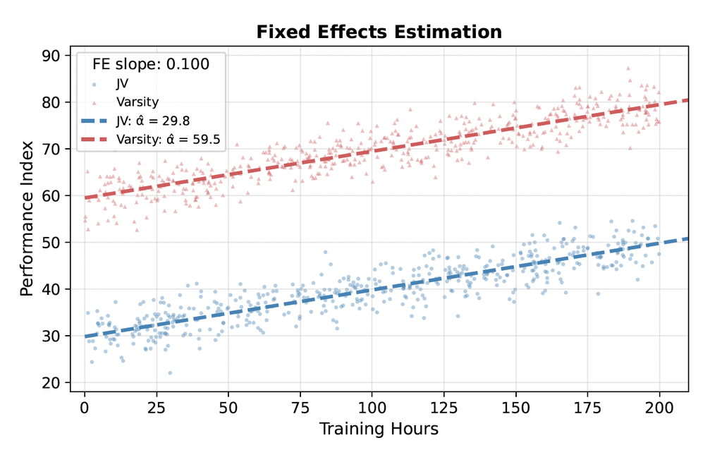

Figura 7: Inclinação com interceptos específicos = **0,100** (verdadeira = 0,10).

Interceptos:

- JV = **29,8** (verdadeiro = 30);
- Varsity = **59,5** (verdadeiro = 60).

## MQO agrupado versus interceptos específicos

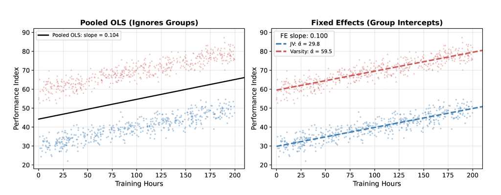

Figura 8: esq. MQO agrupado (ignora os grupos). dir. modelo com interceptos específicos por grupo.

## Heterogeneidade não observada

### Relação com dados em painel

- Neste exemplo simulado, JV e Varsity possuem **diferentes níveis de habilidade não observada**, que geram interceptos distintos no desempenho: 30 para a JV e 60 para a Varsity.
- A equipe é observada, mas a **habilidade subjacente** que produz essa diferença de nível não precisa ser diretamente observável em uma aplicação real.
- Os interceptos específicos $\alpha_{\text{JV}}$ e $\alpha_{\text{Varsity}}$ absorvem, neste exemplo, essa diferença de nível entre as equipes.
- Em dados em painel, generalizamos essa intuição: cada unidade $i$ pode possuir **heterogeneidade específica da unidade invariável no tempo** ao longo do período observado.
- Na próxima seção, formalizaremos essa heterogeneidade e veremos como ela entra no modelo de efeitos fixos.

Modelo de efeitos fixos: formulação e estimação

## Do JV/Varsity ao painel: o problema do *pooled OLS*

Considere o modelo para a unidade $i$ no período $t$:

$$y_{it}=\beta_0+\beta_1x_{it}+u_i+e_{it}.$$

- $u_i$: heterogeneidade não observada da unidade, **invariável no tempo**;
- $e_{it}$: erro idiossincrático, específico de $i$ e $t$.

Se $u_i$ estiver associado a $x_{it}$, o *pooled OLS* pode ser inconsistente: o erro composto $v_{it}=u_i+e_{it}$ contém uma variável omitida relevante.

É o mecanismo visto em JV/Varsity: a **habilidade não observada** difere entre as equipes, desloca o desempenho esperado e, quando também está associada às horas de treinamento, pode distorcer a inclinação do MQO agrupado.

O *pooled OLS* combina **diferenças entre unidades** e **mudanças dentro da mesma unidade**. Queremos isolar esta última fonte de informação.

## O erro do modelo tem dois componentes

No modelo básico,

$$y_{it}=\beta_0+\beta_1x_{it}+v_{it},
\qquad
v_{it}=u_i+e_{it}.$$

O **erro composto** $v_{it}$ reúne dois tipos diferentes de fatores não observados.

**$u_i$: heterogeneidade específica da unidade invariável no tempo**

Representa fatores não observados que diferem entre as unidades, mas permanecem constantes ao longo do período observado.

*Exemplos:* habilidade não observada de um trabalhador, qualidade gerencial não observada de uma empresa ou características históricas de um estado.

**$e_{it}$: erro idiossincrático**

Representa fatores não observados que podem variar **entre unidades e ao longo do tempo**.

*Exemplos:* um choque temporário de demanda em uma empresa ou uma mudança específica no mercado de trabalho de um estado em determinado ano.

## O erro do modelo tem dois componentes

Efeitos fixos eliminam $u_i$, mas **não eliminam $e_{it}$**.

Após a transformação *within*, o erro passa a ser

$$e_{it}-\bar e_i.$$

## Como controlar a heterogeneidade invariável no tempo?

Duas estratégias principais permitem eliminar a heterogeneidade específica da unidade invariável no tempo:

1. **Primeiras diferenças:** subtrair observações da mesma unidade em períodos consecutivos.
2. **Efeitos fixos (*within*):** trabalhar com desvios em relação à média da própria unidade.

Nos dois casos, o componente $u_i$, que não varia ao longo do tempo, **desaparece da equação transformada**.

A diferença está na transformação utilizada:

- primeiras diferenças comparam **períodos consecutivos**;
- efeitos fixos comparam cada observação com a **média da própria unidade**.

## Primeiras diferenças com $T=2$

Observe a mesma unidade em dois períodos:

$$\begin{aligned}
y_{i1}&=\beta_0+\beta_1x_{i1}+u_i+e_{i1},\\
y_{i2}&=\beta_0+\beta_1x_{i2}+u_i+e_{i2}.
\end{aligned}$$

Subtraia a primeira equação da segunda:

$$\begin{aligned}
y_{i2}-y_{i1}
&=(\beta_0-\beta_0)+\beta_1(x_{i2}-x_{i1})\\
&\quad +(u_i-u_i)+(e_{i2}-e_{i1}).
\end{aligned}$$

O intercepto comum e a heterogeneidade individual invariável no tempo **desaparecem**.

## Primeiras diferenças: interpretação e papel

A equação transformada é

$$\Delta y_i=\beta_1\Delta x_i+\Delta e_i,$$

em que $\Delta y_i=y_{i2}-y_{i1}$, $\Delta x_i=x_{i2}-x_{i1}$ e $\Delta e_i=e_{i2}-e_{i1}$.

Aplicar MQO a essa equação produz o **estimador de primeiras diferenças**.

A informação vem das **mudanças dentro da mesma unidade**: quanto $x$ e $y$ mudaram entre os períodos.

Como $u_i$ foi eliminado, não precisamos supor que $x_{it}$ seja não correlacionado com essa heterogeneidade invariável no tempo.

Ainda precisamos, porém, de uma hipótese sobre a relação entre $x_{it}$ e o erro idiossincrático $e_{it}$. Vamos formalizá-la adiante.

Também precisamos de variação suficiente em $\Delta x_i$: se $x$ não muda dentro das unidades, sua inclinação não pode ser estimada por primeiras diferenças.

Primeiras diferenças também preparam o terreno para os **modelos dinâmicos em painel**, estudados posteriormente.

## Introduzindo efeitos fixos

No exemplo JV/Varsity, diferentes níveis de **habilidade não observada** geravam interceptos distintos no desempenho esperado. Em dados em painel, generalizamos essa ideia:

$$y_{it}=\alpha_i+\beta_1x_{it}+e_{it},
\qquad
\alpha_i=\beta_0+u_i.$$

$\alpha_i$ é o **efeito fixo da unidade**: reúne o intercepto comum e a heterogeneidade específica da unidade invariável no tempo.

Podemos também controlar fatores que afetam **todas as unidades em determinado período**:

$$y_{it}=\alpha_i+\lambda_t+\beta_1x_{it}+e_{it}.$$

- $\alpha_i$: efeito fixo de **unidade**;
- $\lambda_t$: efeito fixo de **tempo**.

Por exemplo, $\alpha_i$ pode absorver **heterogeneidade específica da unidade invariável no tempo** ao longo do período observado; $\lambda_t$ pode representar uma recessão nacional ou outro choque comum em determinado ano.

Na sequência, veremos como a transformação *within* elimina $\alpha_i$.

## Efeitos fixos em ação

Q O que os efeitos fixos controlam?

R

- **Efeitos fixos de unidade ($\alpha_i$):** controlam a heterogeneidade específica da unidade invariável no tempo.

  *Exemplos:* localização geográfica, características institucionais que não mudam no período observado ou outros fatores invariáveis no tempo.
- **Efeitos fixos de tempo ($\lambda_t$):** controlam choques comuns às unidades em cada período.

  *Exemplos:* uma recessão nacional, uma mudança regulatória geral ou outro choque macroeconômico que afete todas as unidades no mesmo período.

Somente efeitos de unidade: **uma dimensão** (*one-way*).

Efeitos de unidade e tempo: **duas dimensões** (*two-way*).

Com efeitos de unidade e tempo, $\beta_1$ é estimado a partir da **variação dentro da unidade**, descontados os movimentos comuns de tempo.

Efeitos de tempo não controlam automaticamente choques **específicos de cada unidade que variam ao longo do tempo**.

## A transformação/estimador *within*

Para entender como o estimador de efeitos fixos funciona, considere **apenas efeitos de unidade**:

$$y_{it}=\alpha_i+\beta_1x_{it}+e_{it}.$$

Calcule a média temporal de cada unidade:

$$\bar y_i=\alpha_i+\beta_1\bar x_i+\bar e_i.$$

Agora subtraia essa média da equação original:

$$y_{it}-\bar y_i
=\beta_1(x_{it}-\bar x_i)+(e_{it}-\bar e_i).$$

O efeito fixo $\alpha_i$, por ser invariável no tempo, **desaparece**.

Assim, cada observação passa a ser expressa como um desvio em relação à média da própria unidade.

Por exemplo, $x_{it}-\bar x_i$ mostra quanto $x$ no período $t$ está acima ou abaixo do nível médio de $x$ daquela mesma unidade.

Aplicar MQO à equação transformada produz o **estimador de efeitos fixos (*within*)**.

## Duas consequências da transformação

**1. Com $T=2$, FD e *within* produzem a mesma inclinação.**

$$x_{i1}-\bar x_i=-\frac{\Delta x_i}{2},
\qquad
x_{i2}-\bar x_i=\frac{\Delta x_i}{2}.$$

O mesmo vale para $y$: os desvios são primeiras diferenças reescaladas. Para $T>2$, FD e *within* são transformações distintas, sem equivalência numérica em geral.

**2. Uma regressora invariável no tempo desaparece.**

Se acrescentarmos $\gamma w_i$ ao modelo, com $w_i$ constante para cada unidade, então

$$w_i-\bar w_i=0.$$

Como $w_i$ não varia **dentro da unidade**, não há variação *within* que permita estimar separadamente seu efeito.

Por isso, o estimador *within* **não identifica separadamente $\gamma$**.

Isso não significa que $w_i$ não tenha efeito substantivo.

## De onde vem a variação que identifica $\beta_1$?

No modelo com efeitos fixos de unidade, a estimativa de $\beta_1$ **não utiliza as diferenças permanentes de nível entre unidades**.

Por exemplo, comparar uma unidade que sempre apresenta valores maiores de $x$ e $y$ com outra unidade não é o que identifica a inclinação.

A informação vem das mudanças de $x$ dentro da mesma unidade ao longo do tempo:

Essa é a **variação *within***.

Com efeitos fixos de tempo, descontamos também os choques comuns a todas as unidades em cada período.

Assim, $\beta_1$ é identificado pela variação de $x$ **dentro da unidade**, depois de controlar também os movimentos comuns de tempo.

## A exogeneidade estrita continua necessária

Efeitos fixos eliminam $u_i$, mas não eliminam o erro idiossincrático $e_{it}$.

Para estimar consistentemente $\beta_1$, precisamos da hipótese de **exogeneidade estrita**:

$$E(e_{it}\mid X_i,u_i)=0,
\qquad
X_i=(x_{i1},\ldots,x_{iT}).$$

Em particular, essa hipótese implica

$$\operatorname{Cov}(e_{it},x_{is})=0,
\qquad s=1,\ldots,T.$$

Ou seja, não basta que $e_{it}$ seja não correlacionado com $x_{it}$: isso deve valer também para os valores **passados e futuros** da regressora.

**Exemplo de violação:** um choque não observado de demanda em $e_{it}$ aumenta as vendas da empresa hoje e leva a empresa a aumentar o investimento no ano seguinte.

Nesse caso, $e_{it}$ está relacionado a um valor futuro de $x$ e a exogeneidade estrita falha.

FE **não exige que $u_i$ seja não correlacionado com $x_{it}$**.

Mas FE **não resolve endogeneidade envolvendo $e_{it}$**, como a causada por fatores omitidos que variam no tempo e estão associados às regressoras, ou por respostas futuras de $x$ a choques correntes.

Exogeneidade estrita é uma **hipótese do modelo**, não algo que um diagnóstico possa comprovar.

## Salário mínimo: diferenças entre estados

Queremos estudar o emprego de jovens usando um painel de estados ($i$) e anos ($t$).

$$\text{Emprego}_{it}
=\beta_1\text{Salário mínimo}_{it}+\alpha_i+\lambda_t+e_{it}.$$

Esta é uma especificação com **efeitos fixos em duas dimensões (*two-way*)**:

- $\alpha_i$: efeitos fixos de **estado**, que controlam fatores específicos dos estados invariáveis no tempo;
- $\lambda_t$: efeitos fixos de **tempo**, que controlam choques comuns aos estados em cada ano.

## Salário mínimo: diferenças entre estados

Q Devemos nos preocupar simplesmente porque alguns estados têm salário mínimo mais alto que outros?

R Os efeitos de estado controlam **fatores específicos do estado invariáveis no tempo** que podem afetar o emprego e estar associados ao salário mínimo.

Por exemplo: localização geográfica, características históricas e características institucionais que não mudam ao longo do período observado.

A estimativa de $\beta_1$ é utiliza as mudanças do salário mínimo **dentro do mesmo estado**, e não pelas diferenças entre estados que permanecem invariáveis ao longo do período observado.

## Salário mínimo: efeitos comuns de tempo

$$\text{Emprego}_{it}
=\beta_1\text{Salário mínimo}_{it}+\alpha_i+\lambda_t+e_{it}.$$

- $\alpha_i$ absorve diferenças entre estados **invariáveis no tempo**;
- $\lambda_t$ absorve **choques comuns aos estados** no ano $t$.

Q E se alguns anos tiverem emprego mais baixo que outros, como em recessões nacionais?

R O efeito fixo de tempo $\lambda_t$ controla a **componente do choque que é comum a todos os estados** naquele ano.

Por exemplo, uma recessão nacional pode reduzir o emprego de jovens em diversos estados simultaneamente.

Respostas específicas de cada estado à recessão **não são automaticamente absorvidas** pelos efeitos fixos de tempo.

## Salário mínimo: o que ainda deve preocupar?

$$\text{Emprego}_{it}
=\beta_1\text{Salário mínimo}_{it}+\alpha_i+\lambda_t+e_{it}.$$

- $\alpha_i$: diferenças entre estados **invariáveis no tempo**;
- $\lambda_t$: choques **comuns aos estados** em cada ano.

Q Então, com o que ainda devemos nos preocupar?

R Com **fatores específicos do estado que variam ao longo do tempo** e podem afetar o emprego e estar associados ao salário mínimo.

Por exemplo, alguns estados podem apresentar crescimento econômico mais rápido e, ao mesmo tempo, elevar seus salários mínimos.

Se esse crescimento econômico não estiver observado no modelo, seu efeito passa a fazer parte do erro idiossincrático $e_{it}$.

Se ele também estiver associado ao salário mínimo, a regressora estará relacionada ao erro e a **exogeneidade estrita pode falhar**.

Se buscamos interpretar $\beta_1$ causalmente, esse é um exemplo de **confundidor que varia no tempo**.

Efeitos fixos eliminam $u_i$, mas **não eliminam essa fonte de endogeneidade envolvendo $e_{it}$**.

## O que efeitos fixos significam nesse exemplo

Os efeitos fixos de estado $\alpha_i$ controlam **fatores específicos do estado invariáveis no tempo** ao longo do período observado.

Por exemplo:

- localização e outras características geográficas;
- características históricas preexistentes;
- outros componentes estruturais que não mudam entre 2014 e 2021.

Os efeitos fixos de tempo $\lambda_t$ controlam **choques comuns aos estados em cada ano**, como uma recessão nacional.

$$\text{Emprego}_{it}
=\beta_1\text{Salário mínimo}_{it}+\alpha_i+\lambda_t+e_{it}.$$

$\hat\beta_1$ é estimado a partir das mudanças do salário mínimo dentro do mesmo estado, descontados os movimentos comuns aos estados em cada ano.

## Vamos ver esse exemplo simulado graficamente.

Dados simulados, mas um problema econométrico real.

O painel tem 40 estados e oito anos (2014–2021).

Para visualizar as relações, selecionamos seis estados.

## Relação agrupada

[figure not shown]

A reta escura mostra o modelo pooled OLS: nas observações agrupadas, salário mínimo e emprego de jovens se relacionam positivamente. Esse modelo mistura diferenças entre estados e mudanças dentro dos estados.

## Relações dentro dos estados

[figure not shown]

As retas por estado revelam uma relação dentro dos estados negativa, em contraste com a relação pooled positiva. Efeitos fixos de unidade usam essa variação dentro do estado, controlando diferenças de nível entre estados.

## Removendo as médias estaduais

[figure not shown]

Depois de subtrair de cada observação a média de seu estado, os eixos mostram desvios em relação às médias estaduais. A reta escura representa a relação *within* do modelo com efeitos fixos de estado (*one-way*); os efeitos de ano ainda não foram removidos.

## Paradoxo de Simpson

[figure not shown]

A relação agrupada é positiva, enquanto a relação dentro dos estados é negativa: uma reversão de sinal característica do paradoxo de Simpson. O mesmo padrão apareceu no cenário **“JV treina mais”**, ao controlar pela equipe.

## O pacote `fixest`

Nesta aula, usaremos o pacote `fixest` para estimar e apresentar modelos com efeitos fixos.

Duas funções serão particularmente importantes:

- `feols()`: estima modelos lineares por MQO e permite incluir efeitos fixos de forma compacta;
- `etable()`: organiza os modelos estimados em tabelas para comparação.

Nos próximos slides, estimaremos com `feols()`:

- um modelo **pooled OLS**;
- um modelo com efeitos fixos de **estado e ano**.

As tabelas de resultados que veremos foram produzidas com `etable()`.

Na **Atividade 1**, vocês trabalharão mais detalhadamente com o pacote `plm`, desenvolvido especificamente para a análise econométrica de dados em painel.

Nesta aula, `fixest` nos permite concentrar a atenção na **especificação e interpretação dos efeitos fixos**.

## Sintaxe de `fixest`

Para especificar efeitos fixos, use a sintaxe de `lm` seguida de `|` e das variáveis que identificam os efeitos.

```r
feols(
  teen_emp ~ min_wage | state + year,
  cluster = ~ state,
  data = mw_df
)
```

`| state + year` introduz efeitos fixos de estado e ano.

`cluster = ~ state` agrupa a inferência por estado. Sua fundamentação será estudada na Aula 3.

## Saída de `fixest`: pooled OLS e efeitos fixos

Resultados

```
                        est_ols           est_fe
Dependent Var.:        teen_emp         teen_emp

Constant         21.3*** (3.00)
min_wage        2.93*** (0.345) -1.44*** (0.196)
Fixed-Effects:  --------------- ----------------
state                        No              Yes
year                         No              Yes
_______________ _______________ ________________
S.E.: Clustered       by: state        by: state
Observations                320              320
R2                      0.48037          0.96360
Within R2                    --          0.13134
---
Signif. codes: 0 '***' 0.001 '**' 0.01 '*' 0.05 '.' 0.1 ' ' 1
```

## Saída de `fixest`: inclinações diferentes

Resultados

```
                        est_ols           est_fe
Dependent Var.:        teen_emp         teen_emp

Constant         21.3*** (3.00)
min_wage        2.93*** (0.345) -1.44*** (0.196)
Fixed-Effects:  --------------- ----------------
state                        No              Yes
year                         No              Yes
_______________ _______________ ________________
S.E.: Clustered       by: state        by: state
Observations                320              320
R2                      0.48037          0.96360
Within R2                    --          0.13134
---
Signif. codes: 0 '***' 0.001 '**' 0.01 '*' 0.05 '.' 0.1 ' ' 1
```

As duas estimativas de $\beta_1$ são estatisticamente significativas, mas contam histórias muito diferentes.

## Saída de `fixest`: ausência de um único intercepto

Resultados

```
                        est_ols           est_fe
Dependent Var.:        teen_emp         teen_emp

Constant         21.3*** (3.00)
min_wage        2.93*** (0.345) -1.44*** (0.196)
Fixed-Effects:  --------------- ----------------
state                        No              Yes
year                         No              Yes
_______________ _______________ ________________
S.E.: Clustered       by: state        by: state
Observations                320              320
R2                      0.48037          0.96360
Within R2                    --          0.13134
---
Signif. codes: 0 '***' 0.001 '**' 0.01 '*' 0.05 '.' 0.1 ' ' 1
```

Q Por que não aparece um único intercepto $\beta_0$ no modelo FE?

R Porque o modelo inclui **efeitos fixos de estado e de ano**, que absorvem as diferenças de nível associadas a essas duas dimensões.

Assim, um intercepto global não é estimado separadamente desses efeitos fixos.

## Saída de `fixest`: within R²

Resultados

```
                        est_ols           est_fe
Dependent Var.:        teen_emp         teen_emp

Constant         21.3*** (3.00)
min_wage        2.93*** (0.345) -1.44*** (0.196)
Fixed-Effects:  --------------- ----------------
state                        No              Yes
year                         No              Yes
_______________ _______________ ________________
S.E.: Clustered       by: state        by: state
Observations                320              320
R2                      0.48037          0.96360
Within R2                    --          0.13134
---
Signif. codes: 0 '***' 0.001 '**' 0.01 '*' 0.05 '.' 0.1 ' ' 1
```

Q O que é o *within* $R^2$?

R É o $R^2$ **após controlar pelos efeitos fixos**: quanto da variação restante do resultado é explicado pelas regressoras.

## Saída de `fixest`: R² e efeitos fixos

Resultados

```
                        est_ols           est_fe
Dependent Var.:        teen_emp         teen_emp

Constant         21.3*** (3.00)
min_wage        2.93*** (0.345) -1.44*** (0.196)
Fixed-Effects:  --------------- ----------------
state                        No              Yes
year                         No              Yes
_______________ _______________ ________________
S.E.: Clustered       by: state        by: state
Observations                320              320
R2                      0.48037          0.96360
Within R2                    --          0.13134
---
Signif. codes: 0 '***' 0.001 '**' 0.01 '*' 0.05 '.' 0.1 ' ' 1
```

Em relação ao *MQO agrupado*, o modelo FE apresenta $R^2$ muito maior: a inclusão dos efeitos fixos de estado e ano explica uma parcela importante da variação da taxa de emprego associada a diferenças entre estados e entre anos.

## Hipóteses do modelo de efeitos fixos: FE1

**FE1. Especificação do modelo**

$$y_{it} = \beta_0 + \beta_1x_{1it} +\cdots + \beta_Kx_{Kit} + u_i+e_{it}$$

- $u_i$: heterogeneidade não observada da unidade, **invariável no tempo**;
- $e_{it}$: erro idiossincrático, que varia entre unidades e ao longo do tempo.

Variáveis **invariáveis no tempo** desaparecem na transformação *within*; por isso, seus coeficientes não podem ser estimados separadamente dos efeitos fixos de unidade.

Efeitos comuns de tempo também podem ser incluídos, como no modelo *two-way* apresentado anteriormente.

## Hipóteses do modelo de efeitos fixos: FE2

**FE2. Exogeneidade estrita**

$$E(e_{it}\mid X_i,u_i)=0,$$

em que $X_i$ reúne os valores das regressoras da unidade $i$ em **todos os períodos**.

Assim, valores passados, presentes e futuros das regressoras não devem fornecer informação sistemática sobre $e_{it}$.

## Hipóteses do modelo de efeitos fixos: FE3–FE4

**FE3. Homocedasticidade do erro idiossincrático**

$$\operatorname{Var}(e_{it}\mid X_i,u_i)
=
\operatorname{Var}(e_{it})
=
\sigma_e^2.$$

A variância de $e_{it}$ é constante entre unidades e períodos.

**FE4. Independência entre unidades e ausência de correlação serial**

1. As unidades são selecionadas aleatoriamente da população, de modo que os erros de unidades distintas são estatisticamente independentes.
2. Para uma mesma unidade,

$$\operatorname{Cov}(e_{it},e_{is}\mid X_i,u_i)=0,
\qquad t\neq s.$$

Assim, o erro idiossincrático não apresenta **correlação serial**.

Retomaremos essa questão na **Aula 3**, ao estudar inferência robusta a agrupamento.

## Hipóteses do modelo de efeitos fixos: FE5

**FE5. Ausência de colinearidade perfeita e existência de variação**

Não há **colinearidade exata** entre as regressoras e as variáveis observáveis apresentam variação.

Para que seu coeficiente possa ser estimado pelo *within*, uma regressora precisa apresentar **variação dentro das unidades ao longo do tempo**.

Uma regressora invariável no tempo dentro de cada unidade desaparece na transformação *within*.

## Resumo: o que efeitos fixos fazem?

No painel de estados e anos,

$$\text{Emprego}_{it}
=\beta_1\text{Salário mínimo}_{it}+\alpha_i+\lambda_t+e_{it}.$$

**Efeitos fixos de estado ($\alpha_i$)** controlam a heterogeneidade específica do estado invariável no tempo.

*Exemplo:* localização geográfica, características históricas ou outros componentes estruturais que não mudam entre 2014 e 2021.

**Efeitos fixos de tempo ($\lambda_t$)** controlam choques comuns aos estados em cada ano.

*Exemplo:* uma recessão nacional que reduza o emprego de jovens em vários estados no mesmo ano.

A inclinação $\beta_1$ é estimada a partir da variação do salário mínimo dentro do mesmo estado, descontados os movimentos comuns de tempo.

Em outras palavras: quando um estado muda seu salário mínimo, como varia seu emprego de jovens em relação à sua própria trajetória?

## Resumo: o que efeitos fixos não resolvem?

Mesmo após controlar por efeitos fixos de estado e de tempo, a interpretação de $\hat\beta_1$ ainda exige cautela.

**Confundidores que variam ao longo do tempo**

*Exemplo:* um estado pode passar por forte crescimento econômico, aumentando o emprego de jovens e, ao mesmo tempo, elevando seu salário mínimo.

Como esse fator varia de forma específica dentro do estado ao longo do tempo, **não é eliminado automaticamente pelos efeitos fixos de estado e de tempo**.

**Causalidade reversa**

*Exemplo:* mudanças nas condições do mercado de trabalho podem influenciar a própria decisão de alterar o salário mínimo.

Nesse caso, a relação entre salário mínimo e emprego não ocorre necessariamente em apenas uma direção.

## Resumo: o que efeitos fixos não resolvem?

**Pouca variação *within***

Se o salário mínimo muda pouco dentro dos estados ao longo do período, há pouca informação para estimar $\beta_1$ com precisão.

**Estimar $\beta_1$ não garante interpretação causal.**

Uma interpretação causal exige justificar as hipóteses da estratégia empírica.

Atividade 1

## Competências computacionais para pesquisa e prática profissional

Um dos objetivos desta disciplina, assim como de outras disciplinas que ministro, é desenvolver habilidades computacionais úteis tanto para a pesquisa científica quanto para a atuação profissional.

Isso envolve trabalhar de forma organizada com:

- linguagens de programação;
- projetos computacionais;
- controle de versão com Git e GitHub;
- documentos e análises reprodutíveis.

Essas práticas favorecem **reprodutibilidade, transparência e auditabilidade**: o código, os dados e as etapas da análise podem ser examinados, reproduzidos e aperfeiçoados posteriormente.

São competências relevantes na pesquisa e também em organizações públicas e privadas que utilizam dados para análise e tomada de decisão.

## A Atividade 1 inicia o fluxo de trabalho da disciplina

Nesta atividade, você criará o **projeto computacional que utilizará ao longo da disciplina**.

O objetivo não é apenas organizar arquivos. Vamos praticar um fluxo de trabalho que será reutilizado nas próximas aulas:

**GitHub** $\rightarrow$ **projeto RStudio** $\rightarrow$ **estrutura organizada de arquivos** $\rightarrow$ **análise reprodutível com Quarto e R** $\rightarrow$ **controle de versão**

A repetição desse procedimento ao longo das disciplinas faz com que essas práticas deixem de ser etapas adicionais e passem a fazer parte naturalmente do processo de análise.

## Antes de começar

**Ambiente computacional**

Para realizar a atividade, você deve ter disponível:

- R;
- RStudio;
- Quarto;
- Git configurado;
- conta no GitHub.

Se necessário, atualize RStudio e Quarto antes de iniciar a atividade.

## Atividade 1

### Criando Projeto RStudio com Git/GitHub

**1. Crie um Repositório no GitHub**

- Acesse sua conta no GitHub: github.com
- Selecione “**Create repository**”
- No campo abaixo de **Repository name**, digite o nome do repositório.
- Nome recomendado: **mpa_ecnt3_2026**
- **NÃO USE** acentos, espaços vazios ou caracteres especiais. Utilize apenas letras, números, hífens (-) ou underscores (_).
- **MARQUE** as caixas para criar `README` e `.gitignore` apenas.
- **Não** é necessário selecionar uma licença.
- Agora, apenas clique em “**Create repository**”, no canto inferior esquerdo da página.
- Em seguida, será exibida a página do repositório recém-criado; deixe esta aba do navegador aberta.

## Atividade 1

### Criando Projeto RStudio com Git/GitHub

**2. Crie um Projeto RStudio - Parte 1**

- Abra o RStudio
- Clique em **Project: (None)** no canto **superior direito**
- Na próxima janela, clique em **Version Control**
- Na próxima janela, clique em **Git**, será exibida uma nova janela a ser preenchida
- Volte à página do repositório do GitHub e **copie** o endereço exibido após o **HTTPS**, algo parecido com:

`https://github.com/nomeusuario/mpa_ecnt3_2026.git`

## Atividade 1

### Criando Projeto RStudio com Git/GitHub

**2. Crie um Projeto RStudio - Parte 2**

- Volte ao RStudio.
- Cole o endereço do repositório no campo **Repository URL**
- No campo **Project directory name** digite: **mpa_ecnt3_2026**
- Clique no botão **Browse** e **clique uma vez no nome da pasta** do seu computador na qual salvará seu projeto RStudio e em **Abrir** (ou Salvar)
- Clique em **Create Project** e o projeto RStudio será criado.
- Na aba **Files** do RStudio, você verá três arquivos:
  - `.gitignore`
  - `mpa_ecnt3_2026.Rproj`
  - `README.md`

## Arquivo .gitignore

**Instruções**

Abra o arquivo `.gitignore` do seu projeto, apague o conteúdo existente, copie e cole o conteúdo exibido abaixo e salve o arquivo.

```markdown
# Arquivos de sistema do Windows
Thumbs.db
Desktop.ini

# Arquivos do RStudio
.Rproj.user/
.Rhistory
.RData
.Ruserdata

# Arquivos temporários R
*_cache/
/cache/

# Arquivos de saída
*.pdf
*.html
*.docx

# Arquivos temporários
*~
.~lock.*
*.tmp
*.bak
```

## Atividade 1

### Criando Projeto RStudio com Git/GitHub

**Pastas e Arquivos**

- **Crie** a seguinte estrutura de pastas e arquivos para seu projeto da disciplina.
- Recomendo que você use o arquivo `README.md` para documentar seu processo de aprendizagem ao longo da disciplina.

```
mpa_ecnt3_2026/
├── atividades/
│   └── 01-atividade/
│       └── 01-atividade.qmd
├── dados/
│   └── brutos/
│       ├── equipes-varsity-treina-mais.csv
│       └── Data_AgricultureClimate.csv
├── .gitignore
├── mpa_ecnt3_2026.Rproj
└── README.md
```

## Atividade 1

### Arquivos da atividade

**Organização**

- Descompacte o arquivo `01-atividade.zip` e coloque o arquivo `01-atividade.qmd` dentro da subpasta `atividades/01-atividade`
- Coloque os arquivos `equipes-varsity-treina-mais.csv` e o arquivo `Data_AgricultureClimate.csv` dentro da subpasta `dados/brutos`
- Teste a execução das primeiras células de código (*chunks*) do arquivo `01-atividade.qmd` para verificar se a estrutura está correta.

## Atividade 1

### Registre a primeira versão do projeto

**Comandos conhecidos**

Depois de organizar os arquivos e verificar que `01-atividade.qmd` encontra os dados corretamente, execute, um de cada vez, os comandos que você já conhece para **registrar e enviar a primeira versão do projeto ao GitHub**:

```bash
# Verifica o estado atual dos arquivos do repositório
git status
```

```bash
# Adiciona as alterações à área de preparação para o próximo commit
git add .
```

```bash
# Confirma quais alterações serão incluídas no próximo commit
git status
```

```bash
# Registra a primeira versão do projeto no histórico do Git
git commit -m "Configura estrutura inicial do projeto"
```

```bash
# Envia os commits da branch main para o repositório remoto no GitHub
git push origin main
```

## Atividade 1

### Resultado esperado

Ao concluir esta etapa, você deverá ter:

- um **repositório GitHub** para a disciplina;
- um **projeto RStudio** associado a esse repositório;
- a estrutura de pastas definida para o projeto;
- os arquivos de dados em `dados/brutos/`;
- o arquivo `01-atividade.qmd` em `atividades/01-atividade/`;
- os caminhos relativos funcionando corretamente;
- a primeira versão do projeto registrada com **Git** e enviada ao **GitHub**.

A partir desse ambiente organizado e versionado, abra `01-atividade.qmd` e execute a atividade seguindo o roteiro apresentado no próprio documento.

## Referências

BALTAGI, B. H. **[Econometric Analysis of Panel Data](https://doi.org/10.1007/978-3-030-53953-5)**. 6. ed. Cham: Springer, 2021.

CROISSANT, Y.; MILLO, G. **[Panel Data Econometrics with R](https://doi.org/10.1002/9781119504641)**. [s.l.] John Wiley & Sons, 2018.

HILL, R. C.; GRIFFITHS, W. E.; LIM, G. C. **Principles of Econometrics**. 5. ed. Hoboken, NJ: John Wiley & Sons, 2018.

WOOLDRIDGE, J. M. **Econometric Analysis of Cross Section and Panel Data**. 2. ed. Cambridge, MA: The MIT Press, 2010.

___. **Introductory Econometrics: A Modern Approach**. 8. ed. [s.l.] Cengage Learning, 2025.